# Week 3 Activity: Recursive Sequences

Consider the sequence $\{a_n\}$ recursively defined via $$a_{1}=1, \quad a_{n+1}=\frac{3+a_{n}}{2} \quad(n \geqslant 1).$$ Such sequences are called recursive sequences, where each term is defined in terms of the previous term. We'll try to determine if such sequences converge and if so find their limit. Let's take a look at the first $10$ terms of this sequence $a_{1}=1, \quad a_{n+1}=\dfrac{3+a_{n}}{2} \quad(n \geqslant 1).$:

```python
a1=1
a2=(3+a1)/2
a3=(3+a2)/2
a4=(3+a3)/2
a5=(3+a4)/2
a6=(3+a5)/2
a7=(3+a6)/2
a8=(3+a7)/2
a9=(3+a8)/2
a10=(3+a9)/2
print("The value of a1 is",a1)
print("The value of a2 is",a2)
print("The value of a3 is",a3)
print("The value of a4 is",a4)
print("The value of a5 is",a5)
print("The value of a6 is",a6)
print("The value of a7 is",a7)
print("The value of a8 is",a8)
print("The value of a9 is",a9)
print("The value of a10 is",a10)
```

```
The value of a1 is 1
The value of a2 is 2.0
The value of a3 is 2.5
The value of a4 is 2.75
The value of a5 is 2.875
The value of a6 is 2.9375
The value of a7 is 2.96875
The value of a8 is 2.984375
The value of a9 is 2.9921875
The value of a10 is 2.99609375
```

## Your Turn

Write a code that calculates and prints the first $10$ terms of this sequence $a_{1}=1, \quad a_{n+1}=\dfrac{3-a_{n}}{3} \quad(n \geqslant 1).$:

```python
#Enter your code here
```

Before we describe how to determine if a recursive sequence converges, we first introduce some terminology.

We call $\{a_n\}$ **bounded** if it is both bounded above and bounded below.

Based on our calculations above, we see that this sequence is bounded below by $1$ and bounded above by $3$.

But, we can also say this sequence is bounded below by $0$ and bounded above by $5$, or this sequence is bounded below by $-1$ and bounded above by $100$. Clearly, these values are not unique!

This brings us the notion of the least upper bound and the smallest upper bound.

$\alpha$ is called the **least upper bound** of $\{a_n\}$ if:

- $\alpha$ is an upper bound, and
- $\alpha$ is the smallest upper bound, that is, if $\alpha'$ is another upper bound of $\{a_n\}$, then $\alpha^{\prime} \geq \alpha$.

Similarly, $\beta$ is called the **greatest lower bound** of $\{a_n\}$ if:

- $\beta$ is a lower bound, and
- $\beta$ is the largest lower bound, that is, if $\beta'$ is another lower bound of $\{a_n\}$, then $\beta'\leq \beta$.

The code below will calculate the first $10$ terms of the same sequence $a_{1}=1, \quad a_{n+1}=\dfrac{3+a_{n}}{2} \quad(n \geqslant 1).$ using a more efficient method, using a for loop:

```python
a = 1  # a1
print("The value of a1 is", a)

for n in range(2, 11):  # from a2 to a10
    a = (3 + a) / 2
    print("The value of a" + str(n) + " is", a)
```

```
The value of a1 is 1
The value of a2 is 2.0
The value of a3 is 2.5
The value of a4 is 2.75
The value of a5 is 2.875
The value of a6 is 2.9375
The value of a7 is 2.96875
The value of a8 is 2.984375
The value of a9 is 2.9921875
The value of a10 is 2.99609375
```

Based on our calculations above, we say the greatest lower bound of $\{a_n\}$ is $1$ and the least upper bound $\{a_n\}$ is $3$.

An important class of sequences are monotonic sequences, which we define formally as follows: We say that a sequence $\left\{a_{n}\right\}$ is:

- **increasing** if $ a_{n} \leq a_{n+1}$ for all $n\in\mathbb{N}$.
- **strictly increasing** if $ a_{n} < a_{n+1}$ for all $n\in\mathbb{N}$.
- **decreasing** if $ a_{n} \geq a_{n+1}$ for all $n\in\mathbb{N}$.
- **strictly decreasing** if $ a_{n} > a_{n+1}$ for all $n\in\mathbb{N}$. Finally, a sequence $\left\{a_{n}\right\}$ is **monotonic** (or monotone) if it is either decreasing or increasing.

Let's look at the sequence $$a_{1}=1, \quad a_{n+1}= a_n + \dfrac{(-1)^n}{n} \quad(n \geqslant 1).$$

```python
a1 = 1  # initial term
print("The value of a1 is", a1)

a = a1  # use a as the current term
for n in range(2, 11):
    a = a + ((-1) ** n) / n
    print("The value of a" + str(n) + " is", a)
```

```
The value of a1 is 1
The value of a2 is 1.5
The value of a3 is 1.1666666666666667
The value of a4 is 1.4166666666666667
The value of a5 is 1.2166666666666668
The value of a6 is 1.3833333333333335
The value of a7 is 1.2404761904761907
The value of a8 is 1.3654761904761907
The value of a9 is 1.2543650793650796
The value of a10 is 1.3543650793650797
```

As you can see the terms of this sequence increase and then decrease and then increase and then decrease, not behaving monotonicly. Let's take a look at another recursive sequence. Consider the sequence $\{a_n\}$ recursively defined via $$a_{1}=2, \quad a_{n+1}=\sqrt{7+a_{n}} \quad(n \geqslant 1).$$ For fun, let's take a look at the first $20$:

```python
import math
a = 2  # a1
print(f"a1 = {a}")

for n in range(2, 21):  # a2 to a20
    a = math.sqrt(7 + a)
    print(f"a{n} = {a}")
```

```
a1 = 2
a2 = 3.0
a3 = 3.1622776601683795
a4 = 3.187832752853948
a5 = 3.1918384597053073
a6 = 3.192465890139675
a7 = 3.1925641559943125
a8 = 3.192579545758306
a9 = 3.192581955997106
a10 = 3.192582333471935
a11 = 3.1925823925894123
a12 = 3.192582401847979
a13 = 3.1925824032979913
a14 = 3.192582403525082
a15 = 3.1925824035606474
a16 = 3.1925824035662176
a17 = 3.1925824035670898
a18 = 3.1925824035672266
a19 = 3.192582403567248
a20 = 3.1925824035672514
```

Based on our calculations above, we see that $\{a_n\}$ is an increasing sequence. But we also observe that the terms of this sequence stabilize at around the value $3.19$. We'll call this the limit of {a_n}. Figure below gives us a better picture of this scenario.

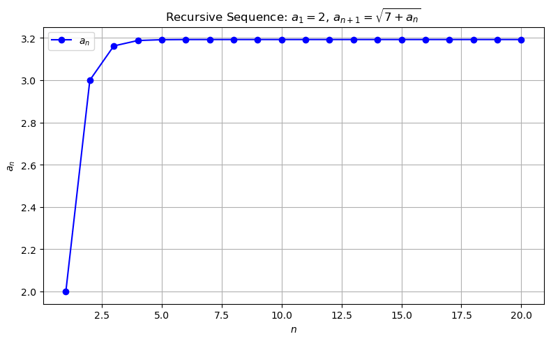

```python
import math
import matplotlib.pyplot as plt

# Initialize first term
a = 2
terms = [a]  # list to store a_n values

# Generate next 19 terms (up to a20)
for _ in range(19):
    a = math.sqrt(7 + a)
    terms.append(a)

# Prepare n values
n_values = list(range(1, 21))

# Plot the sequence
plt.figure(figsize=(8, 5))
plt.plot(n_values, terms, marker='o', linestyle='-', color='blue', label=r'$a_n$')
plt.title(r'Recursive Sequence: $a_1 = 2$, $a_{n+1} = \sqrt{7 + a_n}$')
plt.xlabel(r'$n$')
plt.ylabel(r'$a_n$')
plt.grid(True)
plt.legend()
plt.tight_layout()
plt.show()
```

## Your Turn

Write a code **using a for loop** that calculates and prints the first $20$ terms of this sequence $a_{1}=1, \quad a_{n+1}=\dfrac{3-a_{n}}{3} \quad(n \geqslant 1)$ to determine if the stabilize at around a value. (Hint: Copy and paste one of the codes with for loop and modify it)

```python
import matplotlib.pyplot as plt

# Initialize first term
a = 2
terms = [a]  # list to store a_n values

# Generate next 19 terms (up to a20)
for _ in range(19):
    a = math.sqrt(7 + a)
    terms.append(a)

# Prepare n values
n_values = list(range(1, 21))

# Plot the sequence
plt.figure(figsize=(8, 5))
plt.plot(n_values, terms, marker='o', linestyle='-', color='blue', label=r'$a_n$')
plt.title(r'Recursive Sequence: $a_1 = 2$, $a_{n+1} = \sqrt{7 + a_n}$')
plt.xlabel(r'$n$')
plt.ylabel(r'$a_n$')
plt.grid(True)
plt.legend()
plt.tight_layout()
plt.show()
```

[output not shown]

The following theorem allows us to conclude whether monotonic sequences converge and is an important tool we will use for recursive sequences.

## Monotonic Convergence Theorem (MCT)

Let $\left\{a_{n}\right\}$ be an increasing sequence.

- If $\left\{a_{n}\right\}$ is bounded above, then $\left\{a_{n}\right\}$ converges to $L=\mathrm{lub}\left(\left\{a_{n}\right\}\right)$.
- If $\left\{a_{n}\right\}$ is not bounded above, then $\left\{a_{n}\right\}$ diverges to $\infty$.

Similarly, let $\left\{b_{n}\right\}$ be a decreasing sequence.

- If $\left\{b_{n}\right\}$ is bounded below, then $\left\{b_{n}\right\}$ converges to $L=\mathrm{glb}\left(\left\{b_{n}\right\}\right)$.
- If $\left\{b_{n}\right\}$ is not bounded below, then $\left\{b_{n}\right\}$ diverges to $-\infty$.

**Recall:** The recursive sequence $a_{1}=2, \quad a_{n+1}=\sqrt{7+a_{n}} \quad(n \geqslant 1)$ was increasing and bounded above, and it was converging. This verifies MCT.

**Questions to think about:**

- (TRUE or FALSE) If $\left\{a_{n}\right\}$ is bounded, then $\left\{a_{n}\right\}$ converges.

**Enter your answer here:**

```python
#You can use this cell to enter a code to help you.
```

- (TRUE or FALSE) If $\left\{a_{n}\right\}$ is not monotonic, then $\left\{a_{n}\right\}$ never converges.

**Enter your answer here:**

```python
#You can use this cell to enter a code to help you.
```

- (TRUE or FALSE) If $\left\{a_{n}\right\}$ converges, then $\left\{a_{n}\right\}$ is bounded.

**Enter your answer here:**

```python
#You can use this cell to enter a code to help you.
```